# Monte Carlo Examples

Lecture 26

March 27, 2026

# Review

## Monte Carlo

- Stochastic simulation: propagate random variables $X$ through model $f$ and want to estimate $\mathbb{E}[f(X)] \approx \sum_{i=1}^n f(X_i)$ using samples $X_1, \ldots, X_n$.
- Example: probability of a standard Gaussian between $[0.8, 0.9]$: draw $X_1, \ldots, X_n \sim N(0, 1)$,
  $$f(x) = \mathbb{I}_{[0.8, 0.9]}(x).$$

## Statistics of Monte Carlo

- Denote $Y = f(X)$, $\mathbb{E}[Y] = \mu$, and $\sum_{i=1}^n Y_i = \tilde{\mu}_n$.
- MC is **unbiased**: $\mathbb{E}[\tilde{\mu}_n] = \mu$;
- Monte Carlo standard error (MCSE): $Y_i$ i.i.d., then $\text{SE}(\tilde{\mu}_n) = \sigma_Y / \sqrt{n}$.

## Monte Carlo Confidence Intervals

The $\alpha$-confidence interval is:
$$\tilde{\mu}_n \pm \Phi^{-1}\left(1 - \frac{\alpha}{2}\right) \frac{\sigma_Y}{\sqrt{n}}$$

For example, the 95% confidence interval is
$$\tilde{\mu}_n \pm 1.96 \frac{\sigma_Y}{\sqrt{n}}.$$

## How Many Samples Do I Need?

Try:

1. Run a “pilot” MC with a relatively small number of samples to estimate $\mathbb{V}\left[Y_i\right]$.
2. Pick a target MCSE $\varepsilon$, then we need $N \approx \mathbb{V}\left[Y_i\right] / \varepsilon^2$ samples.
3. Run the “real” MC with sample size $N$ and check if the MCSE is right ($N$ might be off due to error in the variance estimate).
4. If not, run more.

# Airshed Modeling

## Airshed Model

[figure not shown]

Figure 1: Illustration of the airshed, including notation.

**Goal**: Find the probability of exceeding the 1-hour SO<sub>2</sub> average exposure concentration standard, which is 0.14 ppm.

$$\mathbb{P}[\text{SO}_2(\theta) > 0.14] = \int \mathbb{I}(\text{SO}_2(\theta) > 0.14) p(\theta) d\theta$$

## Airshed Model

[figure not shown]

Figure 2: Illustration of the airshed, including notation.

$$\frac{dC}{dt} = \frac{u}{L} C_\text{in} + \frac{S-D}{WHL} - \left(\frac{u}{L} + k\right)C$$

## Forward Euler Discretization

$$\frac{dC}{dt} = \frac{u}{L} C_\text{in}(t) + \frac{S-D}{WHL} - \left(\frac{u}{L} + k\right)C$$

$$\Rightarrow \frac{C(t+1) - C(t)}{\Delta t} = \frac{u}{L} C_\text{in}(t) + \frac{R}{WHL} - \left(\frac{u}{L} + k\right)C(t)$$

$$\bbox[yellow, 10px, border:5px solid red]{C(t+1) = \left(1 - \Delta t\left(\frac{u}{L} + k\right)\right)C(t) + \Delta t \left(\frac{u}{L} C_\text{in}(t) + \frac{R}{WHL}\right)}$$

## Monte Carlo Samples

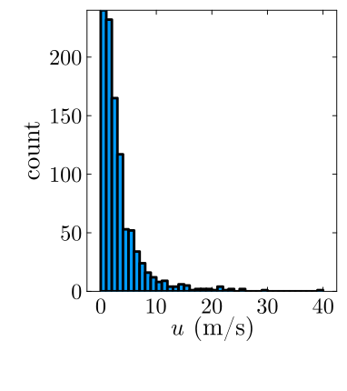

(a) Monte Carlo samples for the airshed model.

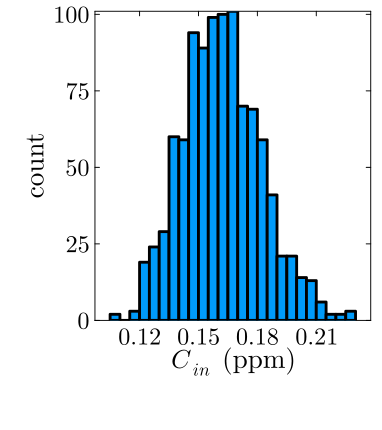

(b)

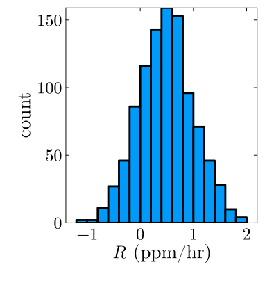

(c)

Figure 3

```julia
nsamp = 1000
u = rand(LogNormal(log(2), 1), nsamp)
Cin = rand(LogNormal(log(0.16), 0.12), nsamp)
R = rand(Normal(0.5, 0.5), nsamp)

p1 = histogram(u, ylabel="count", xlabel=L"$u$ (m/s)", label=false,  size=(400, 450))
p2 = histogram(Cin, ylabel="count", xlabel=L"$C_{in}$ (ppm)", label=false, size=(400, 450))
p3 = histogram(R, ylabel="count", xlabel=L"$R$ (ppm/hr)", label=false,  size=(400, 450))
display(p1)
display(p2)
display(p3)
```

## Simulation Results: Pilot Run

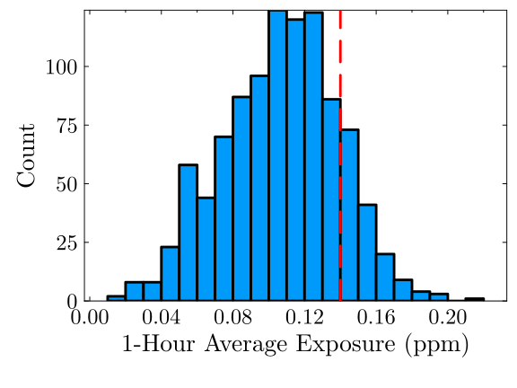

(a) Monte Carlo samples for the airshed model.

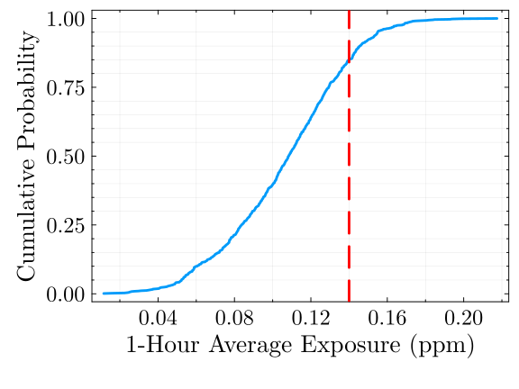

(b)

Figure 4

```julia
# other parameters
C₀ = 0.07
T = 60
k = 0.3
W = 4
H = 5
L = 4
# conduct simulation
P = u / L .* Cin
l = u / L .+ k
C2 = zeros(T*100 + 1, nsamp)
S = 0:0.01:T
for (i, t) in pairs(S)
    if i == 1
        C2[i, :] .= C₀
    else
        C2[i, :] = (1 .- 0.01*l) .* C2[i-1, :] .+ 0.01 * P .+ 0.01 * R / (H * W * L)
    end
end
mean_SO2 = map(mean, eachcol(C2)) # calculate means
# plot histogram
p1 = histogram(mean_SO2, xlabel="1-Hour Average Exposure (ppm)", ylabel="Count", legend=false, tickfontsize=16, guidefontsize=18)
vline!(p1, [0.14], color=:red, linestyle=:dash, linewidth=3)
xticks!(p1, 0:0.04:0.3)
xaxis!(p1, xminorticks=2)
plot!(p1, size=(600, 450))
# plot cdf
p2 = plot(sort(mean_SO2), (1:nsamp) ./ nsamp, xlabel="1-Hour Average Exposure (ppm)", ylabel="Cumulative Probability", legend=false, linewidth=3)
vline!(p2, [0.14], linestyle=:dash, color=:red, linewidth=3, minorgrid=true)
xticks!(p2, 0:0.04:0.3)
xaxis!(p2, xminorticks=2)
yaxis!(p2, yminorticks=5)
plot!(p2, size=(600, 450))

display(p1)
display(p2)
```

## What Sample Size?

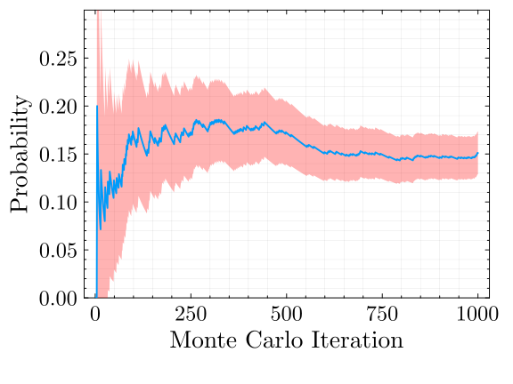

Figure 5: Monte Carlo estimation for the airshed model.

```julia
# show Monte Carlo estimate stabilization
avg_mc_out = zeros(nsamp)
avg_mc_out[1] = mean_SO2[1] > 0.14
std_mc_out = zeros(nsamp)
std_mc_out[1] = 0
for i = 2:nsamp
    avg_mc_out[i] = (avg_mc_out[i-1] * (i-1) + (mean_SO2[i] > 0.14)) / i
    std_mc_out[i] = 1/sqrt(i) * std(mean_SO2[1:i] .> 0.14)
end
p = plot(avg_mc_out, xlabel="Monte Carlo Iteration", ylabel="Probability", left_margin=3mm, legend=:false, ribbon=1.96*std_mc_out, fillalpha=0.3, linewidth=2, fillcolor=:red, right_margin=5mm, minorgrid=true)
ylims!(p, (0, 0.3))
yaxis!(p, yminorticks=5)
plot!(p, size=(600, 450))
display(p)
```

$\hat{\sigma}_n^2 = \mathbb{V}\left[\mathbb{I}[x_{1:n} > 0.14]\right]$

$\hat{\sigma}_n^2 =$ 0.13

If we want to get the MCSE less than 0.01, then we need $N \approx \tilde{\sigma}_n * 10,000$ samples.

## Monte Carlo Estimation: Full Run

Let’s round up and use 20,000 samples.

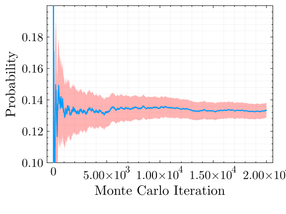

Figure 6: Monte Carlo estimation for the airshed model.

```julia
# show Monte Carlo estimate stabilization
# get new samples
nsamp = 20_000
u = rand(LogNormal(log(2), 1), nsamp)
Cin = rand(LogNormal(log(0.16), 0.12), nsamp)
R = rand(Normal(0.5, 0.5), nsamp)
# conduct simulation
P = u / L .* Cin
l = u / L .+ k
C2 = zeros(T*100 + 1, nsamp)
S = 0:0.01:T
for (i, t) in pairs(S)
    if i == 1
        C2[i, :] .= C₀
    else
        C2[i, :] = (1 .- 0.01*l) .* C2[i-1, :] .+ 0.01 * P .+ 0.01 * R / (H * W * L)
    end
end
mean_SO2 = map(mean, eachcol(C2)) # calculate means

# compute MC Estimate
avg_mc_out = zeros(nsamp)
avg_mc_out[1] = mean_SO2[1] > 0.14
std_mc_out = zeros(nsamp)
std_mc_out[1] = 0
for i = 2:nsamp
    avg_mc_out[i] = (avg_mc_out[i-1] * (i-1) + (mean_SO2[i] > 0.14)) / i
    std_mc_out[i] = 1/sqrt(i) * std(mean_SO2[1:i] .> 0.14)
end
p = plot(avg_mc_out, xlabel="Monte Carlo Iteration", ylabel="Probability", left_margin=3mm, legend=:false, ribbon=1.96*std_mc_out, fillalpha=0.3, linewidth=2, fillcolor=:red, right_margin=5mm, minorgrid=true)
ylims!(p, (0.1, 0.2))
yaxis!(p, yminorticks=5)
plot!(p, size=(600, 450))
display(p)
```

MCSE: 0.002

Estimate: 0.13 $\pm$ 0.005

# Flood Modeling

## Annual Expected Damages

Suppose we have a client who wants us to advise them on their expected flood losses from a nearby stream. The house is worth $400,000 and floods when stream water levels exceed 1.5m.

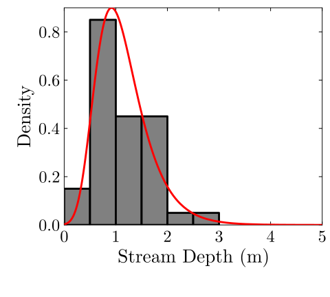

Figure 7: Record of stream water levels

```julia
# load data
true_dist = GeneralizedExtremeValue(0.9, 0.5, 0.16)
depths = rand(true_dist, 40)
# fit GEV distribution
gev_loglik(y, θ) = sum(logpdf.(GeneralizedExtremeValue(θ[1], θ[2], θ[3]), y))
p0 = [0.1, 2.0, 0.0]
lb = [0.0, 0.01, -1.0]
ub = [2.0, 5.0, 1.0]
mle_out = optimize(p -> -gev_loglik(depths, p), lb, ub, p0)
θ_mle = mle_out.minimizer
wl_dist = GeneralizedExtremeValue(θ_mle[1], θ_mle[2], θ_mle[3])

p1 = histogram(depths, legend=false, xlabel="Stream Depth (m)", ylabel="Density", normalize=:pdf, color=:gray)
plot!(p1, wl_dist, color=:red, linewidth=3, normalize=:pdf)
plot!(p1, xlims=(0, 5))
plot!(p1, size=(500, 450))
```

## Depth-Damage Functions

Translating flood depths to damages requires a **depth-damage function**. For this problem:

$$d(h) = \mathbb{I}[h > 0] \frac{1}{1+\exp(-k(x-x_0))},$$

where $k=1.25$ and $x_0=2$.

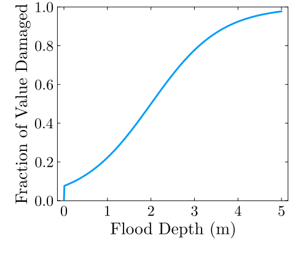

Figure 8: Depth-damage function

```julia
h = 0:0.01:5
dd(h, k, x₀) = (h .> 0) * 1 ./ (1 .+ exp.(-k * (h .- x₀)))
plot(h, dd(h, 1.25, 2), xlabel="Flood Depth (m)", ylabel="Fraction of Value Damaged", legend=false)
ylims!(0, 1)
plot!(size=(500, 450))
```

## Estimating Expected Annual Damages

We want to estimate $\mathbb{E}[d(H)]$, $H + 1.5 \sim \text{GEV}(\mu, \sigma, \xi)$.

How many MC samples do we need? Pilot with 1,000 samples:

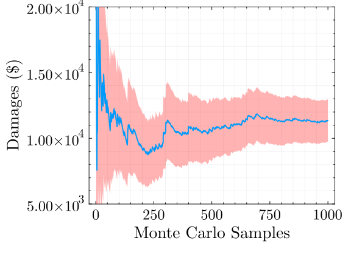

$\tilde{\sigma}_n^2 =$ 6.7e8

If we want to get the MCSE less than $100, then we need $N \approx \tilde{\sigma}_n / 10,000$ samples.

## Monte Carlo Estimate

Let’s round up and use 100,000 samples:

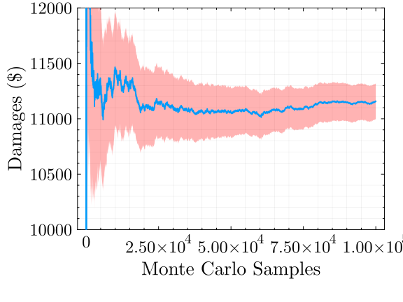

Figure 10: Monte Carlo convergence

MCSE: 82.0

Estimate: 11157.0 $\pm$ 160.0

# Extensions to Optimization

## Stochastic Optimization

Problems typically have the form
$$\min_{a \in \mathcal{A}} \mathbb{E}_X[f(X; a]$$
where

- $\mathcal{A}$ is a set of decision alternatives;
- $f(x; a)$ is the objective function with random realization $x$ and action $a$.

There may also be some constraints on what actions are allowable.

## Example: Home Elevation

Let’s extend the previous example. Suppose our client now wants us to recommend how high they should elevate their house to minimize flooding damages.

- $a \in \mathcal{A}$ are elevation heights;
- $f(x; a)$ is the net cost of elevating with height $a$ and water level realizations $x$:
  $$f(x; a) = \underbrace{D(x; a)}_{\text{flood damages}} + \underbrace{C(a)}_{\text{investment cost}}$$

## Some Notes

- Infrastructure investment problems typically have a **design horizon**: a period of time over which they are designed to be effective. Let’s use 30 years here.
- $X$ is no longer water levels from a single year, as before, but **stochastic sequences of 30-year water levels**.

## Some Notes

- Due to the time value of money, we need to **discount** future benefits with some discount rate $\gamma$ to calculate the **net present value (NPV)** of benefits:
  $$NPV = \sum_{t=0}^T x_t (1-\gamma)^t.$$
- Cost function: $C(\Delta h) = \mathbb{I}[h > 0](C_0 + C_1\Delta h)$.

# Upcoming Schedule

## Next Classes

**Next Week**: Spring Break

**After That**: The Bootstrap and Sampling Uncertainty

# References

## References (Scroll for Full List)